# Лабораторная работа № 5

Эмуляция и измерение потерь пакетов в глобальных сетях

Шуваев С. А.

Российский университет дружбы народов, Москва, Россия

# Информация

## Докладчик

- Шуваев Сергей Александрович
- студент
- Российский университет дружбы народов
- 1032224269@pfur.ru
- https://Grinders060050.github.io/ru/

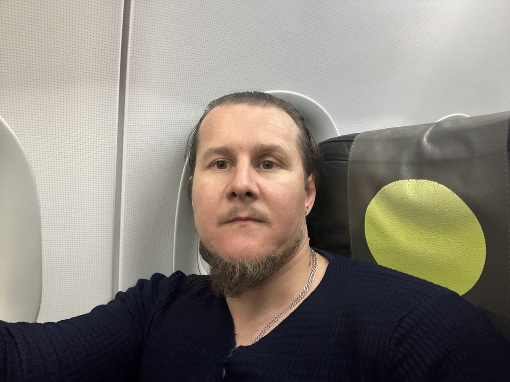

## Цель работы

Основной целью работы является получение навыков проведения интерактивных экспериментов в среде Mininet по исследованию параметров сети, связанных с потерей, дублированием, изменением порядка и повреждением пакетов при передаче данных. Эти параметры влияют на производительность протоколов и сетей.

## Задание

1. Задайте простейшую топологию, состоящую из двух хостов и коммутатора с назначенной по умолчанию mininet сетью 10.0.0.0/8.
2. Проведите интерактивные эксперименты по по исследованию параметров сети, связанных с потерей, дублированием, изменением порядка и повреждением пакетов при передаче данных.
3. Реализуйте воспроизводимый эксперимент по добавлению правила отбрасывания пакетов в эмулируемой глобальной сети. На экран выведите сводную информацию о потерянных пакетах.
4. Самостоятельно реализуйте воспроизводимые эксперименты по исследованию параметров сети, связанных с потерей, изменением порядка и повреждением пакетов при передаче данных. На экран выведите сводную информацию о потерянных пакетах.

## Выполнение лабораторной работы

[figure not shown]

Информацию о сетевых интерфейсах и IP-адресах хостов

## Выполнение лабораторной работы

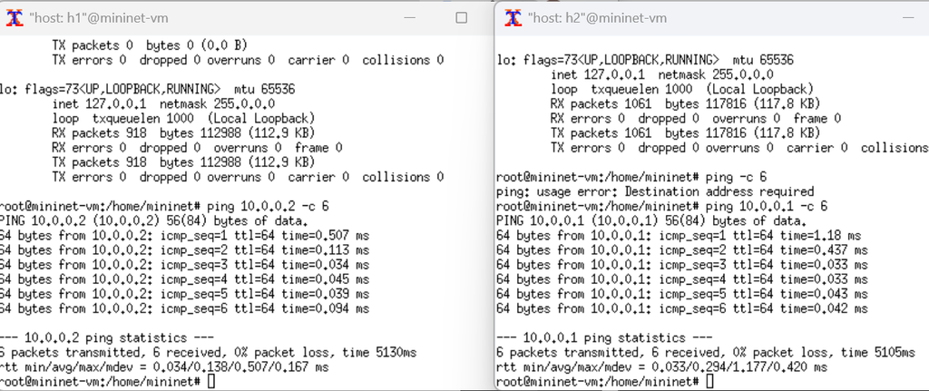

Проверка соединения между хостами

## Выполнение лабораторной работы

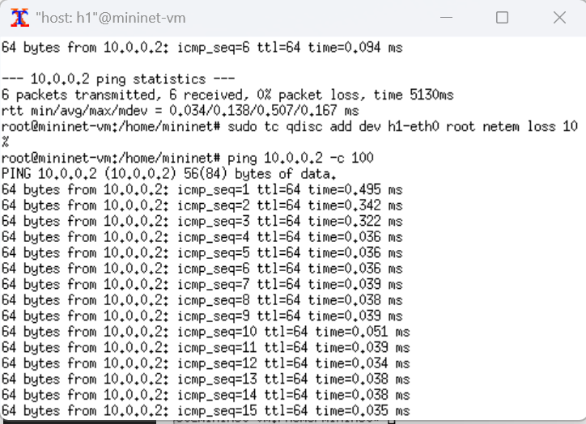

Добавление потери пакетов

## Выполнение лабораторной работы

[figure not shown]

Добавление потери пакетов

## Выполнение лабораторной работы

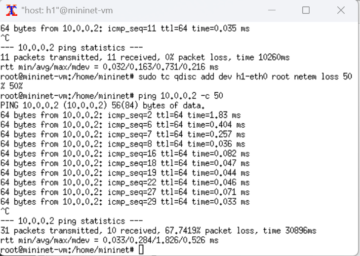

Добавление значения корреляции для потери пакетов

## Выполнение лабораторной работы

[figure not shown]

Добавление повреждения пакетов

## Выполнение лабораторной работы

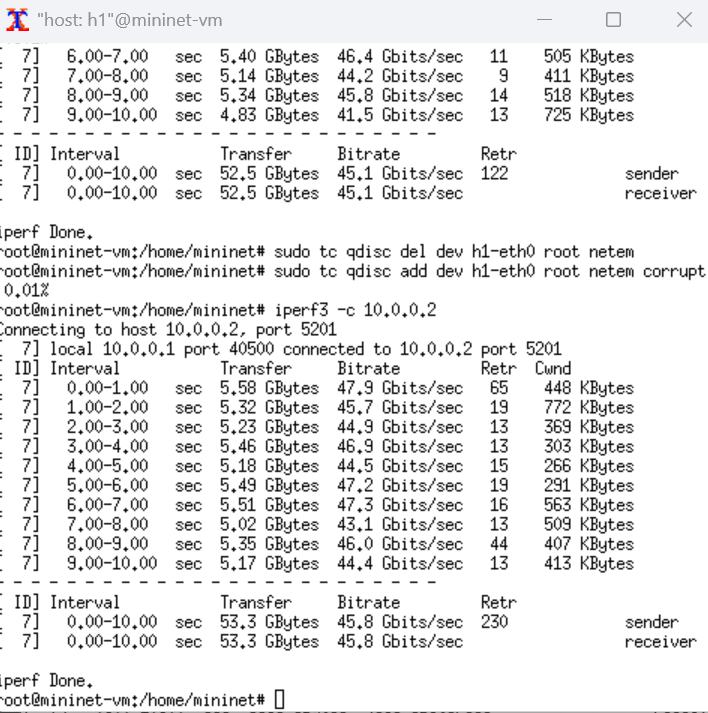

## Выполнение лабораторной работы

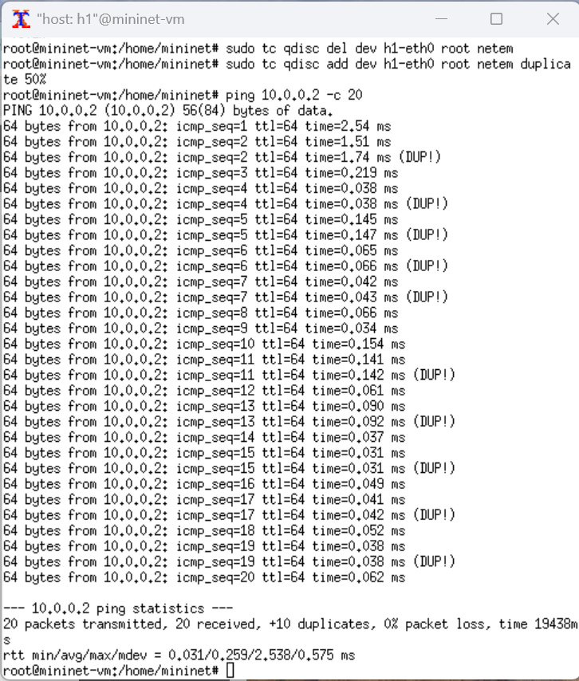

Добавление дублирования пакетов

## Выполнение лабораторной работы

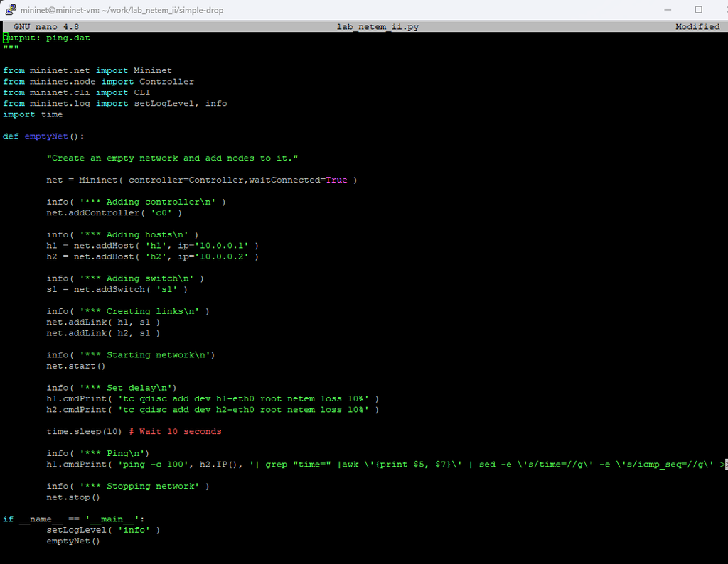

Создание скрипта для эксперимента lab_netem_ii.py

## Выполнение лабораторной работы

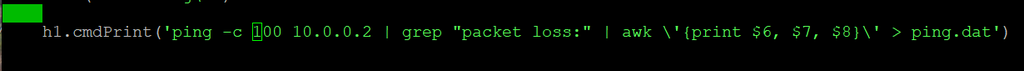

Редактирование сркипта

## Выполнение лабораторной работы

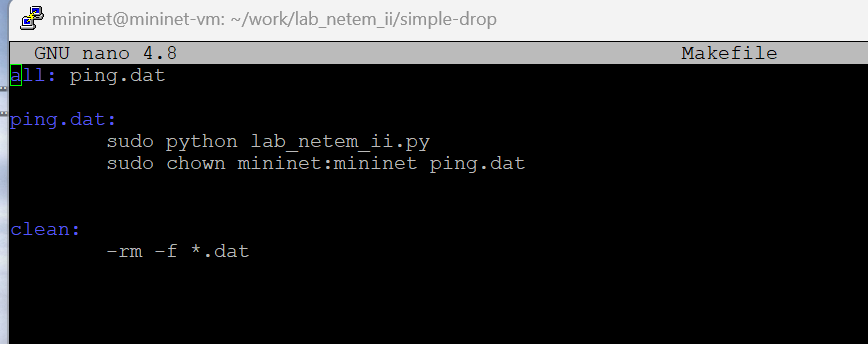

Makefile

## Выполнение лабораторной работы

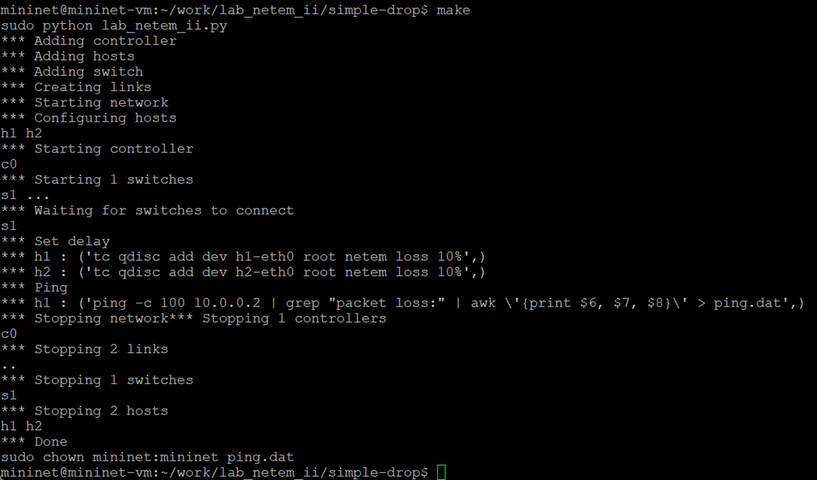

Проведение эксперимента

## Выводы

В результате выполнения данной лабораторной работы я получил навыки проведения интерактивных экспериментов в среде Mininet по исследованию параметров сети, связанных с потерей, дублированием, изменением порядка и повреждением пакетов при передаче данных.

## Список литературы

1. Mininet [Электронный ресурс]. Mininet Project Contributors. URL: http://mininet.org/ (дата обращения: 17.11.2024).